# Variable Selection

Library & data imports

```r
library(lme4)
library(lmerTest)
library(tidyverse)

df <- read.csv("cafo-wq-data-rev.csv")
```

## Data cleaning

```r
# format date column
df$date <- as.Date(df$date, format = '%m/%d/%y')

# extract month from date as new column
df <- df |>
  mutate(month = month(date))

# convert columns to factors where necessary
df <- df |>
  mutate(
    huc8id = as.factor(huc8id),
    huc10id = as.factor(huc10id),
    huc12id = as.factor(huc12id),
    station_id = as.factor(station_id),
    stationcategory = as.factor(stationcategory),
    month = as.factor(month)
  )
```

Scale predictors

```r
huc12_df <- df |>
  mutate(
    # all cafo metrics
    huc12_upstream_cafo_density_scaled = huc12_upstream_cafo_density / 0.1,
    huc12_upstream_cafo_count_scaled = huc12_upstream_cafo_count / 10,
    huc12_weighted_cafo_load_scaled = huc12_weighted_cafo_load / 10,
    huc12_nearest_upstream_cafo_dist_scaled = huc12_nearest_upstream_cafo_dist / 1000,

    # poultry
    huc12_upstream_p_cafo_density_scaled = huc12_upstream_poultry_cafo_dens / 0.1,
    huc12_upstream_p_cafo_count_scaled = huc12_upstream_poultry_cafo_coun / 10,
    huc12_weighted_p_cafo_load_scaled = huc12_weighted_poultry_cafo_load / 10,
    huc12_nearest_p_upstream_cafo_dist_scaled = huc12_nearest_upstream_poultry_c / 1000,

    # other cafo metrics
    huc12_upstream_other_cafo_density_scaled = huc12_upstream_other_cafo_densit / 0.1,
    huc12_upstream_other_cafo_count_scaled = huc12_upstream_other_cafo_count / 10,

    # swine cafo metrics
    huc12_upstream_s_cafo_density_scaled = huc12_upstream_swine_cafo_densit / 0.1,
    huc12_upstream_s_cafo_count_scaled = huc12_upstream_swine_cafo_count / 10
  )
```

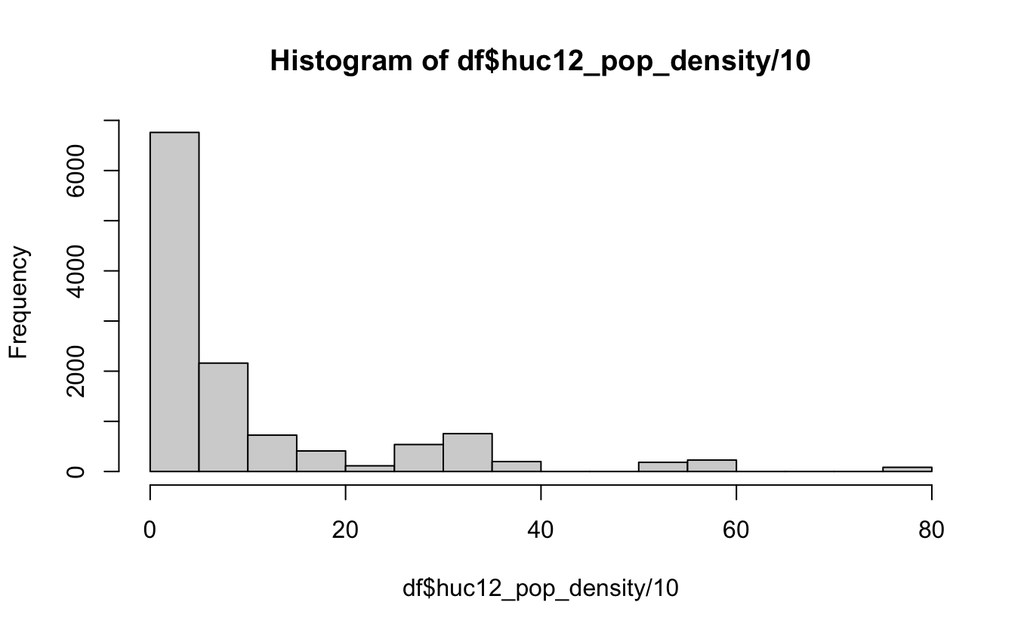

```r
hist(df$huc12_pop_density / 10)
```

### Helper function to run stepwise selection

This will select the covariates and random effects to include in a model for each predictor. Then, it will display the model comparison metrics for the selected model for each predictor so that we can determine which predictor to use.

Running stepwise selection on all predictors and all covariates at the same time results in only covariates being selected for the final model, despite including a predictor resulting in better model comparison metrics.

This can be reused for model selection across all spatial scales and response variables by changing the function inputs.

```r
cafo_model_selection <- function(data, response, predictors, confounding_vars) {

  full_models <- list()
  step_results <- list()
  selected_models <- list()

  for (predictor in predictors) {

    fixed_effects <- paste(
      c(predictor, confounding_vars),
      collapse = ' + '
    )

    model_formula <- as.formula(
      paste(
        response,
        '~',
        fixed_effects,
        '+ (1 | huc8id / station_id)'
      )
    )

    # since we are doing model comparison, use REML = FALSE
    # when fitting final models it will be changed to REML = TRUE
    full_model <- lmer(
      model_formula,
      data = data,
      REML = FALSE
    )

    # run stepwise selection
    step_result <- step(
      full_model,
      keep = predictor
    )

    selected_model <- get_model(step_result)

    full_models[[predictor]] <- full_model
    step_results[[predictor]] <- step_result
    selected_models[[predictor]] <- selected_model
  }

  # print evaluation metrics for selected model for each predictor
  model_summary <- data.frame(
    response = response,
    predictor = names(selected_models),
    AIC = sapply(selected_models, AIC),
    BIC = sapply(selected_models, BIC),
    logLik = sapply(selected_models, function(x) as.numeric(logLik(x)))
  ) |>
    arrange(AIC)

  # store best model
  best_predictor <- model_summary$predictor[1]
  best_model <- selected_models[[best_predictor]]

  list(
    response = response,
    full_models = full_models,
    selected_models = selected_models,
    model_summary = model_summary,
    best_predictor = best_predictor,
    best_model = best_model
  )
}
```

## Stepwise selection: All CAFO metrics, spatial scale = huc12

First we will do stepwise selection for all three of the continuous log transformed response variables using the all CAFO types predictor variables.

Scale predictor variables in a way that will make model coefficients more interpretable. Scales were chosen based on range of values for each predictor. Without scaling, models give warnings about variables being on different scales.

Interpretation of coefficients after scaling: expected change in the response for each X unit increase in {predictor variable}

Define predictors and covariates to test in stepwise selection

```r
# scaled cafo predictors to test one at a time
all_cafo_p <- c(
  'huc12_upstream_cafo_density_scaled',
  'huc12_upstream_cafo_count_scaled',
  'huc12_weighted_cafo_load_scaled',
  'huc12_nearest_upstream_cafo_dist_scaled'
)

all_cafo_predictors <- c(
  'huc12_upstream_cafo_density',
  'huc12_upstream_cafo_count',
  'huc12_weighted_cafo_load',
  'huc12_nearest_upstream_cafo_dist'
)

# confounders for backward elimination
confounders <- c(
  'huc12_pop_density',
  'huc12_pct_cropland',
  'huc12_upstream_wastewater_count',
  'huc12_upstream_wastewater_densit',
  'huc12_weighted_wastewater_load',
  'huc12_upstream_landfill_count',
  'huc12_upstream_landfill_density',
  'huc12_weighted_landfill_load',
  'huc12_upstream_other_npdes_count',
  'huc12_upstream_other_npdes_densi',
  'huc12_weighted_other_npdes_load',
  'stationcategory',
  'month'
)
```

Note that huc10id is not included in the random effects in the following models because there is a high degree of confounding between the huc10’s and stations.

### Nitrite/nitrate concentration

```r
nitlog_results <- cafo_model_selection(huc12_df,
                                       response = 'nitlog',
                                       all_cafo_predictors,
                                       confounders)
nitlog_results
```

```
$response
[1] "nitlog"

$full_models
$full_models$huc12_upstream_cafo_density
Linear mixed model fit by maximum likelihood  ['lmerModLmerTest']
Formula: model_formula
   Data: data
      AIC       BIC    logLik -2*log(L)  df.resid
 29353.94  29568.67 -14647.97  29295.94     12113
Random effects:
 Groups            Name        Std.Dev.
 station_id:huc8id (Intercept) 0.2926
 huc8id            (Intercept) 0.2034
 Residual                      0.7988
Number of obs: 12142, groups:  station_id:huc8id, 105; huc8id, 6
Fixed Effects:
                     (Intercept)       huc12_upstream_cafo_density                 huc12_pop_density
                       -0.389864                          0.027080                          0.009532
              huc12_pct_cropland   huc12_upstream_wastewater_count  huc12_upstream_wastewater_densit
                        0.049591                          0.021407                          0.031514
  huc12_weighted_wastewater_load     huc12_upstream_landfill_count   huc12_upstream_landfill_density
                       -0.012875                          0.156931                         -0.092099
    huc12_weighted_landfill_load  huc12_upstream_other_npdes_count  huc12_upstream_other_npdes_densi
                       -0.029786                         -0.034978                          0.049266
 huc12_weighted_other_npdes_load               stationcategoryMCFR               stationcategoryUCFR
                       -0.061760                         -0.504346                         -0.017336
                          month2                            month3                            month4
                        0.045138                         -0.167506                         -0.217414
                          month5                            month6                            month7
                       -0.655359                         -0.703141                         -0.691967
                          month8                            month9                           month10
                       -0.710324                         -0.726429                         -0.198999
                         month11                           month12
                       -0.194608                         -0.096073

$full_models$huc12_upstream_cafo_count
Linear mixed model fit by maximum likelihood  ['lmerModLmerTest']
Formula: model_formula
   Data: data
```

[output cut: 173 more lines]

```
Number of obs: 8438, groups:  station_id:huc8id, 70; huc8id, 6
Fixed Effects:
                     (Intercept)  huc12_nearest_upstream_cafo_dist               stationcategoryMCFR
                        -0.33141                          -0.06471                          -0.56461
             stationcategoryUCFR                            month2                            month3
                        -0.12499                           0.05001                          -0.16321
                          month4                            month5                            month6
                        -0.20402                          -0.60073                          -0.65180
                          month7                            month8                            month9
                        -0.63616                          -0.65223                          -0.65480
                         month10                           month11                           month12
                        -0.18650                          -0.19582                          -0.09630


$model_summary
```

|  | response | predictor | AIC | BIC | logLik |
| --- | --- | --- | --- | --- | --- |
| huc12_nearest_upstream_cafo_dist | nitlog | huc12_nearest_upstream_cafo_dist | 20485.27 | 20612.00 | -10224.63 |
| huc12_weighted_cafo_load | nitlog | huc12_weighted_cafo_load | 29336.43 | 29469.71 | -14650.22 |
| huc12_upstream_cafo_density | nitlog | huc12_upstream_cafo_density | 29340.41 | 29473.69 | -14652.21 |
| huc12_upstream_cafo_count | nitlog | huc12_upstream_cafo_count | 29340.49 | 29473.77 | -14652.24 |

```
$best_predictor
[1] "huc12_nearest_upstream_cafo_dist"

$best_model
Linear mixed model fit by maximum likelihood  ['lmerModLmerTest']
Formula: nitlog ~ huc12_nearest_upstream_cafo_dist + stationcategory +      month + (1 | huc8id/station_id)
   Data: data
      AIC       BIC    logLik -2*log(L)  df.resid
 20485.27  20612.00 -10224.63  20449.27      8420
Random effects:
 Groups            Name        Std.Dev.
 station_id:huc8id (Intercept) 0.2966
 huc8id            (Intercept) 0.2265
 Residual                      0.8033
Number of obs: 8438, groups:  station_id:huc8id, 70; huc8id, 6
Fixed Effects:
                     (Intercept)  huc12_nearest_upstream_cafo_dist               stationcategoryMCFR
                        -0.33141                          -0.06471                          -0.56461
             stationcategoryUCFR                            month2                            month3
                        -0.12499                           0.05001                          -0.16321
                          month4                            month5                            month6
                        -0.20402                          -0.60073                          -0.65180
                          month7                            month8                            month9
                        -0.63616                          -0.65223                          -0.65480
                         month10                           month11                           month12
                        -0.18650                          -0.19582                          -0.09630
```

```r
summary(nitlog_results$best_model)
```

```
Linear mixed model fit by maximum likelihood . t-tests use Satterthwaite's method ['lmerModLmerTest']
Formula: nitlog ~ huc12_nearest_upstream_cafo_dist + stationcategory +      month + (1 | huc8id/station_id)
   Data: data

      AIC       BIC    logLik -2*log(L)  df.resid
  20485.3   20612.0  -10224.6   20449.3      8420

Scaled residuals:
    Min      1Q  Median      3Q     Max
-2.2368 -0.6398 -0.1813  0.6223  2.8125

Random effects:
 Groups            Name        Variance Std.Dev.
 station_id:huc8id (Intercept) 0.08799  0.2966
 huc8id            (Intercept) 0.05132  0.2265
 Residual                      0.64526  0.8033
Number of obs: 8438, groups:  station_id:huc8id, 70; huc8id, 6

Fixed effects:
                                   Estimate Std. Error         df t value             Pr(>|t|)
(Intercept)                        -0.33141    0.13934    9.09240  -2.378             0.041069 *
huc12_nearest_upstream_cafo_dist   -0.06471    0.03912   65.94115  -1.654             0.102832
stationcategoryMCFR                -0.56461    0.12657   61.29155  -4.461            0.0000356 ***
stationcategoryUCFR                -0.12499    0.21914    6.36235  -0.570             0.587999
month2                              0.05001    0.04887 8385.22276   1.023             0.306268
month3                             -0.16321    0.04830 8387.55949  -3.379             0.000730 ***
month4                             -0.20402    0.04780 8368.45021  -4.268            0.0000199 ***
month5                             -0.60073    0.04345 8393.01687 -13.826 < 0.0000000000000002 ***
month6                             -0.65180    0.04311 8393.61897 -15.118 < 0.0000000000000002 ***
month7                             -0.63616    0.04273 8374.66303 -14.887 < 0.0000000000000002 ***
month8                             -0.65223    0.04349 8393.09851 -14.998 < 0.0000000000000002 ***
month9                             -0.65480    0.04339 8393.02783 -15.090 < 0.0000000000000002 ***
month10                            -0.18650    0.04812 8368.45551  -3.876             0.000107 ***
month11                            -0.19582    0.04841 8387.46253  -4.045            0.0000528 ***
month12                            -0.09630    0.04857 8387.54704  -1.983             0.047429 *
---
Signif. codes:  0 ‘***’ 0.001 ‘**’ 0.01 ‘*’ 0.05 ‘.’ 0.1 ‘ ’ 1
```

### Stepwise selection for fecal coliform count

```r
feclog_results <- cafo_model_selection(huc12_df,
                                       response = 'feclog',
                                       all_cafo_predictors,
                                       confounders)
feclog_results
```

```
$response
[1] "feclog"

$full_models
$full_models$huc12_upstream_cafo_density
Linear mixed model fit by maximum likelihood  ['lmerModLmerTest']
Formula: model_formula
   Data: data
      AIC       BIC    logLik -2*log(L)  df.resid
 33921.55  34136.31 -16931.78  33863.55     12127
Random effects:
 Groups            Name        Std.Dev.
 station_id:huc8id (Intercept) 0.4563
 huc8id            (Intercept) 0.3072
 Residual                      0.9606
Number of obs: 12156, groups:  station_id:huc8id, 105; huc8id, 6
Fixed Effects:
                     (Intercept)       huc12_upstream_cafo_density                 huc12_pop_density
                        1.802218                          0.097456                          0.098875
              huc12_pct_cropland   huc12_upstream_wastewater_count  huc12_upstream_wastewater_densit
                        0.190688                         -0.062869                          0.069805
  huc12_weighted_wastewater_load     huc12_upstream_landfill_count   huc12_upstream_landfill_density
                        0.068677                         -0.017451                         -0.002157
    huc12_weighted_landfill_load  huc12_upstream_other_npdes_count  huc12_upstream_other_npdes_densi
                        0.107665                         -0.043785                         -0.231146
 huc12_weighted_other_npdes_load               stationcategoryMCFR               stationcategoryUCFR
                        0.159231                         -0.383760                          0.095445
                          month2                            month3                            month4
                       -0.066202                         -0.100351                         -0.028535
                          month5                            month6                            month7
                       -0.594145                         -0.544726                         -0.533039
                          month8                            month9                           month10
                       -0.470994                         -0.514602                          0.098886
                         month11                           month12
                       -0.016591                          0.008483

$full_models$huc12_upstream_cafo_count
Linear mixed model fit by maximum likelihood  ['lmerModLmerTest']
Formula: model_formula
   Data: data
```

[output cut: 185 more lines]

```
                     (Intercept)  huc12_nearest_upstream_cafo_dist  huc12_upstream_other_npdes_densi
                         2.24753                          -0.09888                          -0.18898
             stationcategoryMCFR               stationcategoryUCFR                            month2
                        -0.86290                          -0.43595                          -0.05085
                          month3                            month4                            month5
                        -0.10450                          -0.06488                          -0.52216
                          month6                            month7                            month8
                        -0.50926                          -0.49028                          -0.41812
                          month9                           month10                           month11
                        -0.46670                           0.09285                          -0.01496
                         month12
                         0.02321


$model_summary
```

|  | response | predictor | AIC | BIC | logLik |
| --- | --- | --- | --- | --- | --- |
| huc12_nearest_upstream_cafo_dist | feclog | huc12_nearest_upstream_cafo_dist | 23061.91 | 23195.69 | -11511.95 |
| huc12_weighted_cafo_load | feclog | huc12_weighted_cafo_load | 33916.14 | 34056.84 | -16939.07 |
| huc12_upstream_cafo_density | feclog | huc12_upstream_cafo_density | 33917.99 | 34043.89 | -16942.00 |
| huc12_upstream_cafo_count | feclog | huc12_upstream_cafo_count | 33918.13 | 34051.43 | -16941.07 |

```
$best_predictor
[1] "huc12_nearest_upstream_cafo_dist"

$best_model
Linear mixed model fit by maximum likelihood  ['lmerModLmerTest']
Formula: feclog ~ huc12_nearest_upstream_cafo_dist + huc12_upstream_other_npdes_densi +
    stationcategory + month + (1 | huc8id/station_id)
   Data: data
      AIC       BIC    logLik -2*log(L)  df.resid
 23061.91  23195.69 -11511.95  23023.91      8423
Random effects:
 Groups            Name        Std.Dev.
 station_id:huc8id (Intercept) 0.4596
 huc8id            (Intercept) 0.3754
 Residual                      0.9329
Number of obs: 8442, groups:  station_id:huc8id, 70; huc8id, 6
Fixed Effects:
                     (Intercept)  huc12_nearest_upstream_cafo_dist  huc12_upstream_other_npdes_densi
                         2.24753                          -0.09888                          -0.18898
             stationcategoryMCFR               stationcategoryUCFR                            month2
                        -0.86290                          -0.43595                          -0.05085
                          month3                            month4                            month5
                        -0.10450                          -0.06488                          -0.52216
                          month6                            month7                            month8
                        -0.50926                          -0.49028                          -0.41812
                          month9                           month10                           month11
                        -0.46670                           0.09285                          -0.01496
                         month12
                         0.02321
```

Best model

```r
summary(feclog_results$best_model)
```

```
Linear mixed model fit by maximum likelihood . t-tests use Satterthwaite's method ['lmerModLmerTest']
Formula: feclog ~ huc12_nearest_upstream_cafo_dist + huc12_upstream_other_npdes_densi +
    stationcategory + month + (1 | huc8id/station_id)
   Data: data

      AIC       BIC    logLik -2*log(L)  df.resid
  23061.9   23195.7  -11512.0   23023.9      8423

Scaled residuals:
    Min      1Q  Median      3Q     Max
-2.8611 -0.6566 -0.2165  0.5951  4.1749

Random effects:
 Groups            Name        Variance Std.Dev.
 station_id:huc8id (Intercept) 0.2113   0.4596
 huc8id            (Intercept) 0.1409   0.3754
 Residual                      0.8704   0.9329
Number of obs: 8442, groups:  station_id:huc8id, 70; huc8id, 6

Fixed effects:
                                   Estimate Std. Error         df t value             Pr(>|t|)
(Intercept)                         2.24753    0.22414    9.48799  10.027           0.00000234 ***
huc12_nearest_upstream_cafo_dist   -0.09888    0.05977   64.62407  -1.654             0.102904
huc12_upstream_other_npdes_densi   -0.18898    0.05433   65.11566  -3.478             0.000905 ***
stationcategoryMCFR                -0.86290    0.19808   64.08503  -4.356           0.00004874 ***
stationcategoryUCFR                -0.43595    0.36027    7.21260  -1.210             0.264415
month2                             -0.05085    0.05678 8382.15726  -0.896             0.370469
month3                             -0.10450    0.05608 8383.76661  -1.863             0.062446 .
month4                             -0.06488    0.05552 8370.79308  -1.169             0.242570
month5                             -0.52216    0.05048 8387.14729 -10.343 < 0.0000000000000002 ***
month6                             -0.50926    0.05009 8387.51689 -10.166 < 0.0000000000000002 ***
month7                             -0.49028    0.04963 8374.53049  -9.878 < 0.0000000000000002 ***
month8                             -0.41812    0.05050 8387.12740  -8.279 < 0.0000000000000002 ***
month9                             -0.46670    0.05040 8387.11761  -9.259 < 0.0000000000000002 ***
month10                             0.09285    0.05588 8370.79243   1.662             0.096648 .
month11                            -0.01496    0.05624 8383.69876  -0.266             0.790196
month12                             0.02321    0.05643 8383.72436   0.411             0.680836
---
Signif. codes:  0 ‘***’ 0.001 ‘**’ 0.01 ‘*’ 0.05 ‘.’ 0.1 ‘ ’ 1
```

### Stepwise selection for phosphorus

In this model, including huc10id did not result in a singular fit warning, but it did not improve the model, so it was excluded for consistency.

```r
phoslog_results <- cafo_model_selection(huc12_df,
                                       response = 'phoslog',
                                       all_cafo_predictors,
                                       confounders)
phoslog_results
```

```
$response
[1] "phoslog"

$full_models
$full_models$huc12_upstream_cafo_density
Linear mixed model fit by maximum likelihood  ['lmerModLmerTest']
Formula: model_formula
   Data: data
      AIC       BIC    logLik -2*log(L)  df.resid
19652.018 19866.746 -9797.009 19594.018     12113
Random effects:
 Groups            Name        Std.Dev.
 station_id:huc8id (Intercept) 0.19835
 huc8id            (Intercept) 0.09952
 Residual                      0.53574
Number of obs: 12142, groups:  station_id:huc8id, 105; huc8id, 6
Fixed Effects:
                     (Intercept)       huc12_upstream_cafo_density                 huc12_pop_density
                       -0.924809                          0.032392                          0.006183
              huc12_pct_cropland   huc12_upstream_wastewater_count  huc12_upstream_wastewater_densit
                        0.016999                          0.046580                         -0.032033
  huc12_weighted_wastewater_load     huc12_upstream_landfill_count   huc12_upstream_landfill_density
                       -0.027647                          0.092724                         -0.025079
    huc12_weighted_landfill_load  huc12_upstream_other_npdes_count  huc12_upstream_other_npdes_densi
                       -0.053803                         -0.085924                          0.068093
 huc12_weighted_other_npdes_load               stationcategoryMCFR               stationcategoryUCFR
                       -0.027178                         -0.602009                         -0.412331
                          month2                            month3                            month4
                        0.010216                          0.007942                          0.044413
                          month5                            month6                            month7
                       -0.246294                         -0.215071                         -0.190470
                          month8                            month9                           month10
                       -0.190930                         -0.198870                          0.147764
                         month11                           month12
                        0.082336                          0.051298

$full_models$huc12_upstream_cafo_count
Linear mixed model fit by maximum likelihood  ['lmerModLmerTest']
Formula: model_formula
   Data: data
```

[output cut: 176 more lines]

```
                     (Intercept)  huc12_nearest_upstream_cafo_dist                 huc12_pop_density
                       -0.879223                         -0.045251                         -0.100523
huc12_upstream_wastewater_densit               stationcategoryMCFR               stationcategoryUCFR
                        0.181069                         -0.674076                         -0.452779
                          month2                            month3                            month4
                        0.010091                          0.008971                          0.055135
                          month5                            month6                            month7
                       -0.213121                         -0.179643                         -0.151380
                          month8                            month9                           month10
                       -0.152868                         -0.163679                          0.176029
                         month11                           month12
                        0.106288                          0.063945


$model_summary
```

|  | response | predictor | AIC | BIC | logLik |
| --- | --- | --- | --- | --- | --- |
| huc12_nearest_upstream_cafo_dist | phoslog | huc12_nearest_upstream_cafo_dist | 13976.08 | 14116.89 | -6968.042 |
| huc12_upstream_cafo_density | phoslog | huc12_upstream_cafo_density | 19640.66 | 19773.94 | -9802.331 |
| huc12_weighted_cafo_load | phoslog | huc12_weighted_cafo_load | 19642.19 | 19775.47 | -9803.093 |
| huc12_upstream_cafo_count | phoslog | huc12_upstream_cafo_count | 19643.67 | 19776.95 | -9803.835 |

```
$best_predictor
[1] "huc12_nearest_upstream_cafo_dist"

$best_model
Linear mixed model fit by maximum likelihood  ['lmerModLmerTest']
Formula: phoslog ~ huc12_nearest_upstream_cafo_dist + huc12_pop_density +
    huc12_upstream_wastewater_densit + stationcategory + month +      (1 | huc8id/station_id)
   Data: data
      AIC       BIC    logLik -2*log(L)  df.resid
13976.083 14116.893 -6968.042 13936.083      8418
Random effects:
 Groups            Name        Std.Dev.
 station_id:huc8id (Intercept) 0.2053
 huc8id            (Intercept) 0.1145
 Residual                      0.5461
Number of obs: 8438, groups:  station_id:huc8id, 70; huc8id, 6
Fixed Effects:
                     (Intercept)  huc12_nearest_upstream_cafo_dist                 huc12_pop_density
                       -0.879223                         -0.045251                         -0.100523
huc12_upstream_wastewater_densit               stationcategoryMCFR               stationcategoryUCFR
                        0.181069                         -0.674076                         -0.452779
                          month2                            month3                            month4
                        0.010091                          0.008971                          0.055135
                          month5                            month6                            month7
                       -0.213121                         -0.179643                         -0.151380
                          month8                            month9                           month10
                       -0.152868                         -0.163679                          0.176029
                         month11                           month12
                        0.106288                          0.063945
```

Best model

```r
summary(phoslog_results$best_model)
```

```
Linear mixed model fit by maximum likelihood . t-tests use Satterthwaite's method ['lmerModLmerTest']
Formula: phoslog ~ huc12_nearest_upstream_cafo_dist + huc12_pop_density +
    huc12_upstream_wastewater_densit + stationcategory + month +      (1 | huc8id/station_id)
   Data: data

      AIC       BIC    logLik -2*log(L)  df.resid
  13976.1   14116.9   -6968.0   13936.1      8418

Scaled residuals:
    Min      1Q  Median      3Q     Max
-2.3787 -0.5982 -0.2185  0.6344  3.2164

Random effects:
 Groups            Name        Variance Std.Dev.
 station_id:huc8id (Intercept) 0.04214  0.2053
 huc8id            (Intercept) 0.01311  0.1145
 Residual                      0.29822  0.5461
Number of obs: 8438, groups:  station_id:huc8id, 70; huc8id, 6

Fixed effects:
                                    Estimate  Std. Error          df t value          Pr(>|t|)
(Intercept)                        -0.879223    0.082364   14.667482 -10.675 0.000000026243075 ***
huc12_nearest_upstream_cafo_dist   -0.045251    0.027079   65.337998  -1.671           0.09948 .
huc12_pop_density                  -0.100523    0.043288   65.195755  -2.322           0.02336 *
huc12_upstream_wastewater_densit    0.181069    0.064896   65.432852   2.790           0.00690 **
stationcategoryMCFR                -0.674076    0.082919   50.747397  -8.129 0.000000000094509 ***
stationcategoryUCFR                -0.452779    0.126076    9.578163  -3.591           0.00527 **
month2                              0.010091    0.033227 8383.370781   0.304           0.76138
month3                              0.008971    0.032835 8385.745971   0.273           0.78470
month4                              0.055135    0.032498 8366.324908   1.697           0.08982 .
month5                             -0.213121    0.029540 8391.330582  -7.215 0.000000000000587 ***
month6                             -0.179643    0.029311 8391.965921  -6.129 0.000000000925188 ***
month7                             -0.151380    0.029052 8372.604923  -5.211 0.000000192565902 ***
month8                             -0.152868    0.029566 8391.415505  -5.170 0.000000239053364 ***
month9                             -0.163679    0.029501 8391.354848  -5.548 0.000000029719279 ***
month10                             0.176029    0.032713 8366.331762   5.381 0.000000076047744 ***
month11                             0.106288    0.032911 8385.647989   3.230           0.00124 **
month12                             0.063945    0.033021 8385.738737   1.937           0.05284 .
---
Signif. codes:  0 ‘***’ 0.001 ‘**’ 0.01 ‘*’ 0.05 ‘.’ 0.1 ‘ ’ 1
```

## Stepwise Selection: Separate CAFO Metrics Models

Prepare predictors and confounding variables

Can’t include distance variables for other and swine CAFO’s because NA values will be dropped and only one unique station_id will be left

```r
# scaled cafo predictors to test one at a time
p_cafo_predictors <- c(
  'huc12_upstream_p_cafo_density_scaled',
  'huc12_upstream_p_cafo_count_scaled',
  'huc12_weighted_p_cafo_load_scaled',
  'huc12_nearest_p_upstream_cafo_dist_scaled'
)

# confounders for backward elimination
p_confounders <- c(
  'huc12_upstream_other_cafo_density_scaled',
  'huc12_upstream_other_cafo_count_scaled',
  'huc12_upstream_s_cafo_density_scaled',
  'huc12_upstream_s_cafo_count_scaled',
  'huc12_pop_density',
  'huc12_pct_cropland',
  'huc12_upstream_wastewater_count',
  'huc12_upstream_wastewater_densit',
  'huc12_weighted_wastewater_load',
  'huc12_upstream_landfill_count',
  'huc12_upstream_landfill_density',
  'huc12_weighted_landfill_load',
  'huc12_upstream_other_npdes_count',
  'huc12_upstream_other_npdes_densi',
  'huc12_weighted_other_npdes_load',
  'stationcategory',
  'month'
)
```

### Nitrite/nitrate Concentration

```r
nitlog_p_results <- cafo_model_selection(huc12_df,
                                       response = 'nitlog',
                                       predictors = p_cafo_predictors,
                                       p_confounders)
nitlog_p_results
```

```
$response
[1] "nitlog"

$full_models
$full_models$huc12_upstream_p_cafo_density_scaled
Linear mixed model fit by maximum likelihood  ['lmerModLmerTest']
Formula: model_formula
   Data: data
      AIC       BIC    logLik -2*log(L)  df.resid
 29357.94  29602.29 -14645.97  29291.94     12109
Random effects:
 Groups            Name        Std.Dev.
 station_id:huc8id (Intercept) 0.2859
 huc8id            (Intercept) 0.2052
 Residual                      0.7988
Number of obs: 12142, groups:  station_id:huc8id, 105; huc8id, 6
Fixed Effects:
                             (Intercept)      huc12_upstream_p_cafo_density_scaled
                               -0.410005                                  0.031046
huc12_upstream_other_cafo_density_scaled    huc12_upstream_other_cafo_count_scaled
                                0.022102                                 -0.670143
    huc12_upstream_s_cafo_density_scaled        huc12_upstream_s_cafo_count_scaled
                               -0.066875                                  0.180822
                       huc12_pop_density                        huc12_pct_cropland
                                0.002766                                  0.053395
         huc12_upstream_wastewater_count          huc12_upstream_wastewater_densit
                                0.025717                                  0.022675
          huc12_weighted_wastewater_load             huc12_upstream_landfill_count
                               -0.009288                                  0.168950
         huc12_upstream_landfill_density              huc12_weighted_landfill_load
                               -0.098092                                 -0.029987
        huc12_upstream_other_npdes_count          huc12_upstream_other_npdes_densi
                               -0.040962                                  0.055506
         huc12_weighted_other_npdes_load                       stationcategoryMCFR
                               -0.071650                                 -0.513887
                     stationcategoryUCFR                                    month2
                                0.014722                                  0.045159
                                  month3                                    month4
                               -0.167485                                 -0.217440
                                  month5                                    month6
```

[output cut: 241 more lines]

```
                                   month2                                     month3
                                  0.07320                                   -0.16320
                                   month4                                     month5
                                 -0.22373                                   -0.65960
                                   month6                                     month7
                                 -0.75300                                   -0.72011
                                   month8                                     month9
                                 -0.77519                                   -0.75305
                                  month10                                    month11
                                 -0.23917                                   -0.20498
                                  month12
                                 -0.07816


$model_summary
```

|  | response | predictor | AIC | BIC | logLik |
| --- | --- | --- | --- | --- | --- |
| huc12_nearest_p_upstream_cafo_dist_scaled | nitlog | huc12_nearest_p_upstream_cafo_dist_scaled | 11293.18 | 11390.69 | -5631.589 |
| huc12_weighted_p_cafo_load_scaled | nitlog | huc12_weighted_p_cafo_load_scaled | 29338.00 | 29471.28 | -14651.001 |
| huc12_upstream_p_cafo_density_scaled | nitlog | huc12_upstream_p_cafo_density_scaled | 29340.06 | 29473.34 | -14652.032 |
| huc12_upstream_p_cafo_count_scaled | nitlog | huc12_upstream_p_cafo_count_scaled | 29341.40 | 29474.68 | -14652.699 |

```
$best_predictor
[1] "huc12_nearest_p_upstream_cafo_dist_scaled"

$best_model
Linear mixed model fit by maximum likelihood  ['lmerModLmerTest']
Formula: nitlog ~ huc12_nearest_p_upstream_cafo_dist_scaled + month +      (1 | station_id:huc8id)
   Data: data
      AIC       BIC    logLik -2*log(L)  df.resid
11293.178 11390.691 -5631.589 11263.178      4904
Random effects:
 Groups            Name        Std.Dev.
 station_id:huc8id (Intercept) 0.3227
 Residual                      0.7492
Number of obs: 4919, groups:  station_id:huc8id, 51
Fixed Effects:
                              (Intercept)  huc12_nearest_p_upstream_cafo_dist_scaled
                                 -0.31891                                   -0.01540
                                   month2                                     month3
                                  0.07320                                   -0.16320
                                   month4                                     month5
                                 -0.22373                                   -0.65960
                                   month6                                     month7
                                 -0.75300                                   -0.72011
                                   month8                                     month9
                                 -0.77519                                   -0.75305
                                  month10                                    month11
                                 -0.23917                                   -0.20498
                                  month12
                                 -0.07816
```

Best formula: nitlog ~ huc12_nearest_p_upstream_cafo_dist_scaled + month + (1 | station_id:huc8id)

```r
summary(nitlog_p_results$best_model)
```

```
Linear mixed model fit by maximum likelihood . t-tests use Satterthwaite's method ['lmerModLmerTest']
Formula: nitlog ~ huc12_nearest_p_upstream_cafo_dist_scaled + month +      (1 | station_id:huc8id)
   Data: data

      AIC       BIC    logLik -2*log(L)  df.resid
  11293.2   11390.7   -5631.6   11263.2      4904

Scaled residuals:
     Min       1Q   Median       3Q      Max
-2.45660 -0.67214  0.07682  0.66864  2.99330

Random effects:
 Groups            Name        Variance Std.Dev.
 station_id:huc8id (Intercept) 0.1041   0.3227
 Residual                      0.5613   0.7492
Number of obs: 4919, groups:  station_id:huc8id, 51

Fixed effects:
                                             Estimate  Std. Error          df t value             Pr(>|t|)
(Intercept)                                 -0.318911    0.083202   83.330765  -3.833             0.000245 ***
huc12_nearest_p_upstream_cafo_dist_scaled   -0.015403    0.009954   51.464020  -1.547             0.127897
month2                                       0.073201    0.058068 4881.882213   1.261             0.207511
month3                                      -0.163202    0.057919 4883.624987  -2.818             0.004855 **
month4                                      -0.223731    0.056975 4869.832788  -3.927            0.0000873 ***
month5                                      -0.659601    0.052374 4888.119505 -12.594 < 0.0000000000000002 ***
month6                                      -0.753003    0.052140 4888.301405 -14.442 < 0.0000000000000002 ***
month7                                      -0.720112    0.051389 4873.865324 -14.013 < 0.0000000000000002 ***
month8                                      -0.775186    0.052440 4888.178845 -14.782 < 0.0000000000000002 ***
month9                                      -0.753049    0.052644 4887.634438 -14.304 < 0.0000000000000002 ***
month10                                     -0.239174    0.056597 4869.687813  -4.226            0.0000242 ***
month11                                     -0.204976    0.058154 4883.621556  -3.525             0.000428 ***
month12                                     -0.078158    0.058345 4883.553113  -1.340             0.180441
---
Signif. codes:  0 ‘***’ 0.001 ‘**’ 0.01 ‘*’ 0.05 ‘.’ 0.1 ‘ ’ 1
```

### Fecal Coliform Counts

```r
feclog_p_results <- cafo_model_selection(huc12_df,
                                       response = 'feclog',
                                       predictors = p_cafo_predictors,
                                       p_confounders)
feclog_p_results
```

```
$response
[1] "feclog"

$full_models
$full_models$huc12_upstream_p_cafo_density_scaled
Linear mixed model fit by maximum likelihood  ['lmerModLmerTest']
Formula: model_formula
   Data: data
      AIC       BIC    logLik -2*log(L)  df.resid
 33928.18  34172.57 -16931.09  33862.18     12123
Random effects:
 Groups            Name        Std.Dev.
 station_id:huc8id (Intercept) 0.4527
 huc8id            (Intercept) 0.3102
 Residual                      0.9606
Number of obs: 12156, groups:  station_id:huc8id, 105; huc8id, 6
Fixed Effects:
                             (Intercept)      huc12_upstream_p_cafo_density_scaled
                               1.7374903                                 0.0659788
huc12_upstream_other_cafo_density_scaled    huc12_upstream_other_cafo_count_scaled
                               0.3230188                                -0.8995166
    huc12_upstream_s_cafo_density_scaled        huc12_upstream_s_cafo_count_scaled
                              -0.0008139                                 0.2043668
                       huc12_pop_density                        huc12_pct_cropland
                               0.0932382                                 0.1901942
         huc12_upstream_wastewater_count          huc12_upstream_wastewater_densit
                              -0.0563419                                 0.0626637
          huc12_weighted_wastewater_load             huc12_upstream_landfill_count
                               0.0646452                                -0.0090424
         huc12_upstream_landfill_density              huc12_weighted_landfill_load
                              -0.0060184                                 0.1071396
        huc12_upstream_other_npdes_count          huc12_upstream_other_npdes_densi
                              -0.0556605                                -0.2260821
         huc12_weighted_other_npdes_load                       stationcategoryMCFR
                               0.1599781                                -0.3889151
                     stationcategoryUCFR                                    month2
                               0.1280252                                -0.0662548
                                  month3                                    month4
                              -0.1004077                                -0.0285366
                                  month5                                    month6
```

[output cut: 249 more lines]

```
         huc12_upstream_other_npdes_densi                                     month2
                                -0.155825                                  -0.036417
                                   month3                                     month4
                                -0.055389                                   0.036369
                                   month5                                     month6
                                -0.485554                                  -0.468752
                                   month7                                     month8
                                -0.451171                                  -0.398769
                                   month9                                    month10
                                -0.446250                                   0.182568
                                  month11                                    month12
                                 0.078942                                   0.049787


$model_summary
```

|  | response | predictor | AIC | BIC | logLik |
| --- | --- | --- | --- | --- | --- |
| huc12_nearest_p_upstream_cafo_dist_scaled | feclog | huc12_nearest_p_upstream_cafo_dist_scaled | 14093.98 | 14217.52 | -7027.992 |
| huc12_upstream_p_cafo_density_scaled | feclog | huc12_upstream_p_cafo_density_scaled | 33914.84 | 34055.55 | -16938.422 |
| huc12_weighted_p_cafo_load_scaled | feclog | huc12_weighted_p_cafo_load_scaled | 33916.89 | 34057.60 | -16939.446 |
| huc12_upstream_p_cafo_count_scaled | feclog | huc12_upstream_p_cafo_count_scaled | 33918.75 | 34052.05 | -16941.373 |

```
$best_predictor
[1] "huc12_nearest_p_upstream_cafo_dist_scaled"

$best_model
Linear mixed model fit by maximum likelihood  ['lmerModLmerTest']
Formula: feclog ~ huc12_nearest_p_upstream_cafo_dist_scaled + huc12_pct_cropland +
    huc12_weighted_landfill_load + huc12_upstream_other_npdes_densi +      month + (1 | huc8id/station_id)
   Data: data
      AIC       BIC    logLik -2*log(L)  df.resid
14093.985 14217.517 -7027.992 14055.985      4904
Random effects:
 Groups            Name        Std.Dev.
 station_id:huc8id (Intercept) 0.3870
 huc8id            (Intercept) 0.3454
 Residual                      0.9938
Number of obs: 4923, groups:  station_id:huc8id, 51; huc8id, 6
Fixed Effects:
                              (Intercept)  huc12_nearest_p_upstream_cafo_dist_scaled
                                 1.876304                                  -0.009158
                       huc12_pct_cropland               huc12_weighted_landfill_load
                                 0.141995                                   0.103282
         huc12_upstream_other_npdes_densi                                     month2
                                -0.155825                                  -0.036417
                                   month3                                     month4
                                -0.055389                                   0.036369
                                   month5                                     month6
                                -0.485554                                  -0.468752
                                   month7                                     month8
                                -0.451171                                  -0.398769
                                   month9                                    month10
                                -0.446250                                   0.182568
                                  month11                                    month12
                                 0.078942                                   0.049787
```

```r
summary(feclog_p_results$best_model)
```

```
Linear mixed model fit by maximum likelihood . t-tests use Satterthwaite's method ['lmerModLmerTest']
Formula: feclog ~ huc12_nearest_p_upstream_cafo_dist_scaled + huc12_pct_cropland +
    huc12_weighted_landfill_load + huc12_upstream_other_npdes_densi +      month + (1 | huc8id/station_id)
   Data: data

      AIC       BIC    logLik -2*log(L)  df.resid
  14094.0   14217.5   -7028.0   14056.0      4904

Scaled residuals:
    Min      1Q  Median      3Q     Max
-2.6457 -0.6285 -0.0401  0.6131  3.9098

Random effects:
 Groups            Name        Variance Std.Dev.
 station_id:huc8id (Intercept) 0.1497   0.3870
 huc8id            (Intercept) 0.1193   0.3454
 Residual                      0.9876   0.9938
Number of obs: 4923, groups:  station_id:huc8id, 51; huc8id, 6

Fixed effects:
                                             Estimate  Std. Error          df t value         Pr(>|t|)
(Intercept)                                  1.876304    0.182916   10.247265  10.258 0.00000103160657 ***
huc12_nearest_p_upstream_cafo_dist_scaled   -0.009158    0.013911   45.831191  -0.658          0.51363
huc12_pct_cropland                           0.141995    0.056315   51.488792   2.521          0.01482 *
huc12_weighted_landfill_load                 0.103282    0.044223   46.350318   2.335          0.02390 *
huc12_upstream_other_npdes_densi            -0.155825    0.052535   49.169830  -2.966          0.00464 **
month2                                      -0.036417    0.077028 4884.440700  -0.473          0.63640
month3                                      -0.055389    0.076770 4886.151063  -0.721          0.47064
month4                                       0.036369    0.075575 4872.566741   0.481          0.63038
month5                                      -0.485554    0.069481 4889.485542  -6.988 0.00000000000316 ***
month6                                      -0.468752    0.069170 4889.743089  -6.777 0.00000000001374 ***
month7                                      -0.451171    0.068168 4875.750225  -6.618 0.00000000004019 ***
month8                                      -0.398769    0.069507 4889.469411  -5.737 0.00000001021044 ***
month9                                      -0.446250    0.069811 4889.048788  -6.392 0.00000000017863 ***
month10                                      0.182568    0.075073 4872.507248   2.432          0.01506 *
month11                                      0.078942    0.077142 4886.117395   1.023          0.30620
month12                                      0.049787    0.077396 4886.118231   0.643          0.52007
---
Signif. codes:  0 ‘***’ 0.001 ‘**’ 0.01 ‘*’ 0.05 ‘.’ 0.1 ‘ ’ 1
```

### Phosphorous Concentration

```r
phoslog_p_results <- cafo_model_selection(huc12_df,
                                          response = 'phoslog',
                                          predictors = p_cafo_predictors,
                                          p_confounders)
phoslog_p_results
```

```
$response
[1] "phoslog"

$full_models
$full_models$huc12_upstream_p_cafo_density_scaled
Linear mixed model fit by maximum likelihood  ['lmerModLmerTest']
Formula: model_formula
   Data: data
      AIC       BIC    logLik -2*log(L)  df.resid
19656.052 19900.398 -9795.026 19590.052     12109
Random effects:
 Groups            Name        Std.Dev.
 station_id:huc8id (Intercept) 0.1943
 huc8id            (Intercept) 0.0945
 Residual                      0.5357
Number of obs: 12142, groups:  station_id:huc8id, 105; huc8id, 6
Fixed Effects:
                             (Intercept)      huc12_upstream_p_cafo_density_scaled
                               -0.946556                                  0.034742
huc12_upstream_other_cafo_density_scaled    huc12_upstream_other_cafo_count_scaled
                                0.030812                                 -0.653521
    huc12_upstream_s_cafo_density_scaled        huc12_upstream_s_cafo_count_scaled
                                0.040058                                 -0.097142
                       huc12_pop_density                        huc12_pct_cropland
                               -0.001401                                  0.018255
         huc12_upstream_wastewater_count          huc12_upstream_wastewater_densit
                                0.051065                                 -0.042238
          huc12_weighted_wastewater_load             huc12_upstream_landfill_count
                               -0.024029                                  0.103984
         huc12_upstream_landfill_density              huc12_weighted_landfill_load
                               -0.032376                                 -0.053431
        huc12_upstream_other_npdes_count          huc12_upstream_other_npdes_densi
                               -0.084416                                  0.084726
         huc12_weighted_other_npdes_load                       stationcategoryMCFR
                               -0.047030                                 -0.601981
                     stationcategoryUCFR                                    month2
                               -0.379911                                  0.010293
                                  month3                                    month4
                                0.008008                                  0.044393
                                  month5                                    month6
```

[output cut: 262 more lines]

```
                      stationcategoryUCFR                                     month2
                                -0.223342                                   0.006086
                                   month3                                     month4
                                 0.027823                                   0.075072
                                   month5                                     month6
                                -0.215552                                  -0.178267
                                   month7                                     month8
                                -0.139910                                  -0.164074
                                   month9                                    month10
                                -0.162742                                   0.206189
                                  month11                                    month12
                                 0.145497                                   0.087579


$model_summary
```

|  | response | predictor | AIC | BIC | logLik |
| --- | --- | --- | --- | --- | --- |
| huc12_nearest_p_upstream_cafo_dist_scaled | phoslog | huc12_nearest_p_upstream_cafo_dist_scaled | 7742.384 | 7885.402 | -3849.192 |
| huc12_weighted_p_cafo_load_scaled | phoslog | huc12_weighted_p_cafo_load_scaled | 19638.973 | 19801.870 | -9797.486 |
| huc12_upstream_p_cafo_density_scaled | phoslog | huc12_upstream_p_cafo_density_scaled | 19641.222 | 19774.502 | -9802.611 |
| huc12_upstream_p_cafo_count_scaled | phoslog | huc12_upstream_p_cafo_count_scaled | 19643.700 | 19776.980 | -9803.850 |

```
$best_predictor
[1] "huc12_nearest_p_upstream_cafo_dist_scaled"

$best_model
Linear mixed model fit by maximum likelihood  ['lmerModLmerTest']
Formula: phoslog ~ huc12_nearest_p_upstream_cafo_dist_scaled + huc12_upstream_s_cafo_density_scaled +
    huc12_upstream_s_cafo_count_scaled + huc12_pop_density +
    huc12_pct_cropland + huc12_upstream_wastewater_densit + stationcategory +
    month + (1 | station_id:huc8id)
   Data: data
      AIC       BIC    logLik -2*log(L)  df.resid
 7742.383  7885.402 -3849.192  7698.383      4897
Random effects:
 Groups            Name        Std.Dev.
 station_id:huc8id (Intercept) 0.2021
 Residual                      0.5220
Number of obs: 4919, groups:  station_id:huc8id, 51
Fixed Effects:
                              (Intercept)  huc12_nearest_p_upstream_cafo_dist_scaled
                                -1.014004                                  -0.005066
     huc12_upstream_s_cafo_density_scaled         huc12_upstream_s_cafo_count_scaled
                                 0.177738                                  -0.281287
                        huc12_pop_density                         huc12_pct_cropland
                                -0.096095                                   0.061832
         huc12_upstream_wastewater_densit                        stationcategoryMCFR
                                 0.159888                                  -0.397097
                      stationcategoryUCFR                                     month2
                                -0.223342                                   0.006086
                                   month3                                     month4
                                 0.027823                                   0.075072
                                   month5                                     month6
                                -0.215552                                  -0.178267
                                   month7                                     month8
                                -0.139910                                  -0.164074
                                   month9                                    month10
                                -0.162742                                   0.206189
                                  month11                                    month12
                                 0.145497                                   0.087579
```

Best formula: phoslog ~ huc12_nearest_p_upstream_cafo_dist_scaled + huc12_upstream_s_cafo_density_scaled +  
huc12_upstream_s_cafo_count_scaled + huc12_pop_density +  
huc12_pct_cropland + huc12_upstream_wastewater_densit + stationcategory +  
month + (1 | station_id:huc8id)

```r
summary(phoslog_p_results$best_model)
```

```
Linear mixed model fit by maximum likelihood . t-tests use Satterthwaite's method ['lmerModLmerTest']
Formula: phoslog ~ huc12_nearest_p_upstream_cafo_dist_scaled + huc12_upstream_s_cafo_density_scaled +
    huc12_upstream_s_cafo_count_scaled + huc12_pop_density +
    huc12_pct_cropland + huc12_upstream_wastewater_densit + stationcategory +
    month + (1 | station_id:huc8id)
   Data: data

      AIC       BIC    logLik -2*log(L)  df.resid
   7742.4    7885.4   -3849.2    7698.4      4897

Scaled residuals:
    Min      1Q  Median      3Q     Max
-2.3499 -0.6279  0.0587  0.6798  3.3774

Random effects:
 Groups            Name        Variance Std.Dev.
 station_id:huc8id (Intercept) 0.04085  0.2021
 Residual                      0.27249  0.5220
Number of obs: 4919, groups:  station_id:huc8id, 51

Fixed effects:
                                             Estimate  Std. Error          df t value             Pr(>|t|)
(Intercept)                                 -1.014004    0.086817   61.145942 -11.680 < 0.0000000000000002 ***
huc12_nearest_p_upstream_cafo_dist_scaled   -0.005066    0.006667   50.109263  -0.760             0.450897
huc12_upstream_s_cafo_density_scaled         0.177738    0.064486   51.080170   2.756             0.008087 **
huc12_upstream_s_cafo_count_scaled          -0.281287    0.125023   51.175336  -2.250             0.028785 *
huc12_pop_density                           -0.096095    0.045027   50.569579  -2.134             0.037703 *
huc12_pct_cropland                           0.061832    0.026426   51.625599   2.340             0.023194 *
huc12_upstream_wastewater_densit             0.159888    0.064167   52.139676   2.492             0.015929 *
stationcategoryMCFR                         -0.397097    0.087312   52.359279  -4.548        0.00003241125 ***
stationcategoryUCFR                         -0.223342    0.099445   49.734670  -2.246             0.029186 *
month2                                       0.006086    0.040463 4879.927599   0.150             0.880446
month3                                       0.027823    0.040360 4881.548441   0.689             0.490623
month4                                       0.075072    0.039698 4868.906860   1.891             0.058674 .
month5                                      -0.215552    0.036500 4884.761759  -5.906        0.00000000375 ***
month6                                      -0.178267    0.036337 4885.061014  -4.906        0.00000095975 ***
month7                                      -0.139910    0.035807 4872.060802  -3.907        0.00009459895 ***
month8                                      -0.164074    0.036546 4884.798835  -4.489        0.00000730448 ***
month9                                      -0.162742    0.036688 4884.495646  -4.436        0.00000937129 ***
month10                                      0.206189    0.039434 4868.869768   5.229        0.00000017786 ***
month11                                      0.145497    0.040524 4881.515719   3.590             0.000333 ***
month12                                      0.087579    0.040657 4881.518075   2.154             0.031281 *
---
Signif. codes:  0 ‘***’ 0.001 ‘**’ 0.01 ‘*’ 0.05 ‘.’ 0.1 ‘ ’ 1
```

## To-do:

- Test models with separate metrics for poultry, swine, and other CAFOs in same model
- Fit selected models and evaluate their performance
- Sensitivity analysis